# TReNA: Past, Present, and Future

5/4/2017

## What is TReNA?

It's an R package for:

- Feature selection
- Footprinting
- Functional genomics

## Using TReNA

When using TReNA, you'll need an assay matrix of expression data where:

1. Rows are different genes
2. Columns are different samples

The TReNA package also comes with its own example data:

```r
suppressMessages(library(TReNA))
load(system.file(package="TReNA",
                 "extdata/ampAD.154genes.mef2cTFs.278samples.RData"))
mtx.sub[1:3,1:5]
```

```
##       S11344_TCX S11316_TCX S11431_TCX S11341_TCX S11289_TCX
## ADNP   94.893216  83.284825  79.511862  80.608077  53.166172
## ADNP2  24.279075  18.847705  20.676318  19.959116  17.701390
## ALX3    0.874247   1.285071   1.030784   1.388908   0.620014
```

## Creating and Solving a TReNA Object

```r
trena <- TReNA(mtx.assay = mtx.sub, solver = "lasso")
target.gene <- "MEF2C"
tfs <- setdiff(rownames(mtx.sub), target.gene)
tbl.out <- solve(trena, target.gene, tfs)
```

|  | beta | intercept | gene.cor |
| --- | --- | --- | --- |
| HDX | 7.282790 | 11.86235 | 0.7241906 |
| STAT4 | 3.769835 | 11.86235 | 0.9047599 |
| FOXP2 | 1.617190 | 11.86235 | 0.8196172 |
| LHX6 | 1.076396 | 11.86235 | 0.7146115 |

## TReNA in December 2016

- 3 different "solvers"
  - LASSO
  - Random Forest
  - Bayes Spike
- Footprint Finders
  - Pull out footprints from a:
    - Gene
    - Region

## Distribution Effects

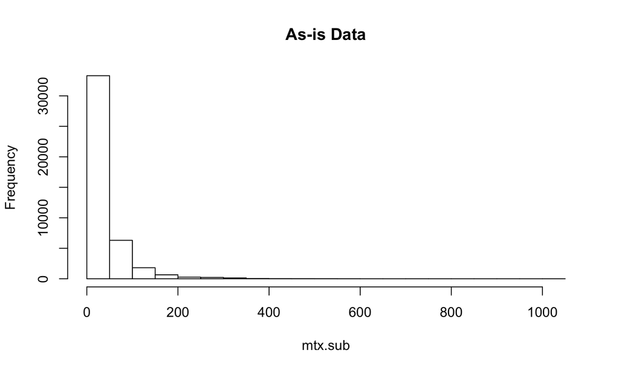

```r
hist(mtx.sub, main = "As-is Data")
```

## Transforming with arcsinh

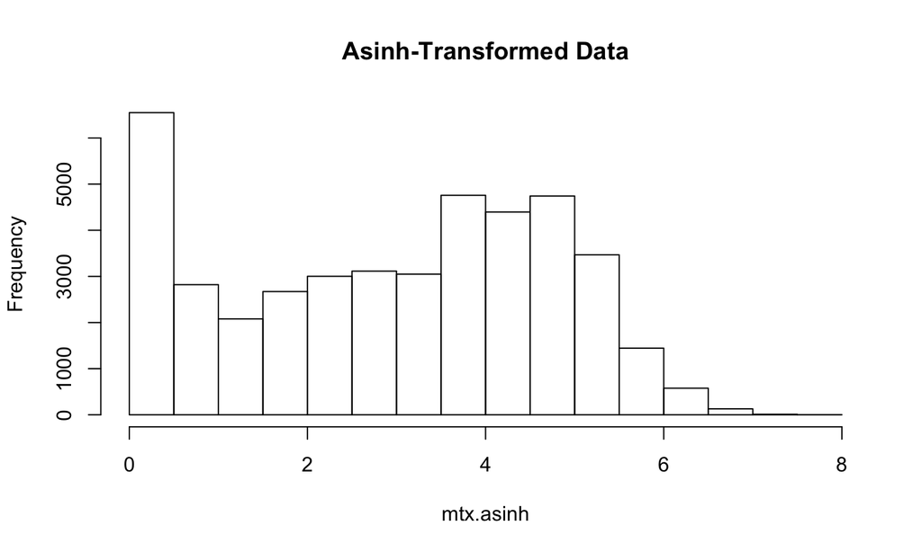

```r
mtx.asinh <- asinh(mtx.sub)
hist(mtx.asinh, main = "Asinh-Transformed Data")
```

## Solvers effects

In addition to the distributions, solver choice can greatly affect results.

```
## [1] --- Testing LASSO
## [1] --- Testing Bayes Spike
## [1] --- Testing Random Forest
## [1] --- Testing Square Root LASSO
```

## Pair Plots

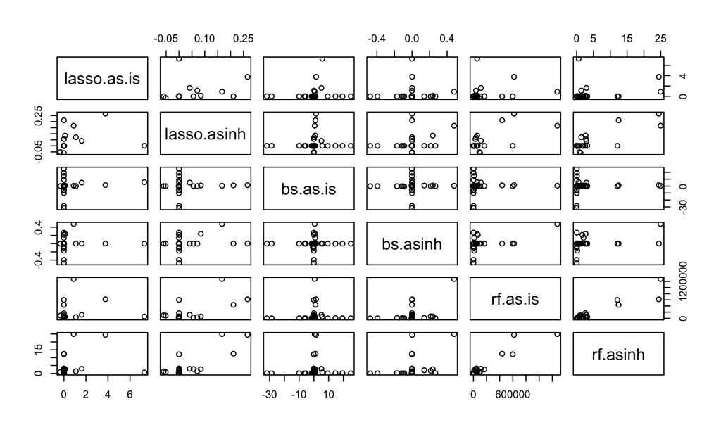

## Correlations

|  | lasso.as.is | lasso.asinh | bs.as.is | bs.asinh | rf.as.is | rf.asinh |
| --- | --- | --- | --- | --- | --- | --- |
| lasso.as.is | 1.000 | 0.330 | 0.120 | 0.061 | 0.220 | 0.300 |
| lasso.asinh | 0.330 | 1.000 | 0.049 | 0.280 | 0.680 | 0.840 |
| bs.as.is | 0.120 | 0.049 | 1.000 | 0.012 | 0.042 | 0.047 |
| bs.asinh | 0.061 | 0.280 | 0.012 | 1.000 | 0.460 | 0.390 |
| rf.as.is | 0.220 | 0.680 | 0.042 | 0.460 | 1.000 | 0.940 |
| rf.asinh | 0.300 | 0.840 | 0.047 | 0.390 | 0.940 | 1.000 |

## Takeaways from Past TReNA

- Distribution matters
  - As-is data is often quite skewed
  - We recommend asinh or VOOM
- Solver choice matters
  - Are 3 solvers sufficient?
  - What else could/should we add?
  - How do we compare between solvers?

## We've Added 5 (6) Solvers

- [Square Root LASSO](https://cran.r-project.org/web/packages/flare/index.html)
- [Pearson Correlation](https://stat.ethz.ch/R-manual/R-devel/library/stats/html/cor.html)
- [Spearman Correlation](https://stat.ethz.ch/R-manual/R-devel/library/stats/html/cor.html)
- [LASSO P-Values](https://cran.r-project.org/web/packages/lassopv/index.html)
- [Ridge Regression](https://cran.r-project.org/web/packages/glmnet/index.html)
- Ensemble Solver

## The Ensemble Solver class

|  | gene | beta.lasso | rf.score | lasso.p.value | beta.ridge | concordance | pcaMax |
| --- | --- | --- | --- | --- | --- | --- | --- |
| 6 | HLF | 0.1667349 | 26.959515 | 0.0000000 | 0.0447146 | 0.6584458 | 4.917574 |
| 11 | STAT4 | 0.2660769 | 20.426830 | 0.0000000 | 0.0363313 | 0.5743943 | 4.390933 |
| 10 | SATB2 | 0.2107348 | 13.241127 | 0.0000000 | 0.0549268 | 0.5403992 | 3.661063 |
| 13 | TSHZ2 | 0.0843242 | 2.981444 | 0.0000000 | 0.0460270 | 0.5527227 | 2.612024 |
| 14 | TSHZ3 | 0.0550247 | 3.293689 | 0.0000000 | 0.0745916 | 0.5682692 | 2.576120 |
| 9 | SATB1 | 0.0000000 | 10.641092 | 0.9571191 | 0.0483654 | 0.6435305 | 2.549424 |

## Examining Solver PCA

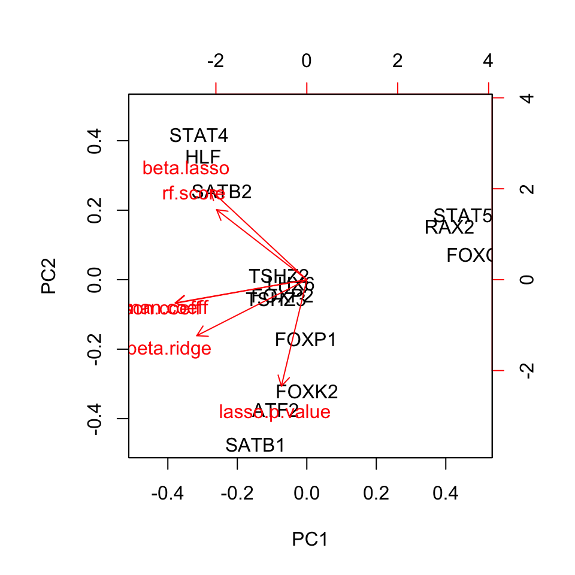

## Examining Solver PCA

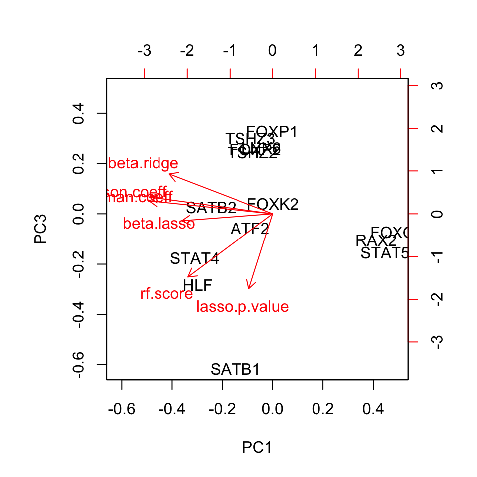

## The CandidateFilter Class

- Feature selection is nice, but nothing new
- Our value added is largely in how we filter predictors
  - VarianceFilter class
  - **FootprintFilter** class

## Using a VarianceFilter

```r
variance.filter <- VarianceFilter(mtx.assay = mtx.asinh)
tf.list <- getCandidates(variance.filter, extraArgs = list("target.gene" = "MEF2C", "var.size" = 0.5))
str(tf.list)
```

```
## List of 2
##  $ tfs    : chr [1:36] "BCL6" "BCL6B" "CREB5" "CUX2" ...
##  $ tf.vars: Named num [1:36] 0.23 0.479 0.28 0.501 0.248 ...
##   ..- attr(*, "names")= chr [1:36] "BCL6" "BCL6B" "CREB5" "CUX2" ...
```

## Using a FootprintFilter

```r
tfs <- getCandidates(footprint.filter, extraArgs)
str(tfs)
```

```
## List of 2
##  $ tfs: chr [1:64] "LHX4" "LHX6" "LHX9" "LHX2" ...
##  $ tbl:'data.frame': 580 obs. of  18 variables:
##   ..$ name      : chr [1:580] "MA0046.2" "MA0046.2" "MA0135.1" "MA0135.1" ...
##   ..$ loc       : chr [1:580] "chr5:88903305-88903319" "chr5:88903305-88903319" "chr5:88903381-88903393" "chr5:88903381-88903393" ...
##   ..$ chrom     : chr [1:580] "chr5" "chr5" "chr5" "chr5" ...
##   ..$ start     : int [1:580] 88903305 88903305 88903381 88903381 88903381 88903381 88903381 88903381 88903381 88903381 ...
##   ..$ endpos    : int [1:580] 88903319 88903319 88903393 88903393 88903393 88903393 88903393 88903393 88903393 88903393 ...
##   ..$ type      : chr [1:580] "motif.in.footprint" "motif.in.footprint" "motif.in.footprint" "motif.in.footprint" ...
##   ..$ length    : int [1:580] 15 15 13 13 13 13 13 13 13 13 ...
##   ..$ strand    : chr [1:580] "+" "-" "+" "+" ...
##   ..$ sample_id : chr [1:580] "ENCSR318PRQ_wellington" "ENCSR318PRQ_wellington" "ENCSR318PRQ_wellington" "ENCSR318PRQ_wellington" ...
##   ..$ method    : chr [1:580] "WELLINGTON" "WELLINGTON" "WELLINGTON" "WELLINGTON" ...
##   ..$ provenance: chr [1:580] "brain.filler.minid" "brain.filler.minid" "brain.filler.minid" "brain.filler.minid" ...
##   ..$ score1    : num [1:580] -23.1 -23.1 -25.9 -25.9 -25.9 ...
##   ..$ score2    : num [1:580] 11.7 12.8 12 12 12 ...
##   ..$ score3    : num [1:580] 3.17e-05 1.69e-05 3.33e-05 3.33e-05 3.33e-05 3.33e-05 3.33e-05 3.33e-05 3.33e-05 3.33e-05 ...
##   ..$ score4    : num [1:580] NA NA NA NA NA NA NA NA NA NA ...
##   ..$ score5    : num [1:580] NA NA NA NA NA NA NA NA NA NA ...
##   ..$ score6    : num [1:580] NA NA NA NA NA NA NA NA NA NA ...
##   ..$ tf        : chr [1:580] "HNF1A" "HNF1A" "LHX4" "LHX6" ...
```

## The FootprintFinder Class

We have public databases of footprints (with more on the way)

```r
genome.db.uri    <- "postgres://bddsrds.globusgenomics.org/hg38"
footprint.db.uri <- "postgres://bddsrds.globusgenomics.org/brain_hint"
fpf <- FootprintFinder(genome.db.uri, footprint.db.uri, quiet=FALSE)
tbl.fp <- getFootprintsInRegion(fpf, "chr5", 88822685, 89011824)
str(tbl.fp)
```

Unfortunately, the databases decided to misbehave right now…

## Summing Up TReNA at Present

Current Workflow:

1. Start with a matrix of expression data
2. Transform the matrix to alter the distribution
3. Use a filter to wean down predictors
4. Run a feature selection with chosen solver

Where do I get TReNA?

- Accepted to Bioconductor Development Branch
- [PriceLab Github](http://trena.org)

## What's Next?

- More databases
  - 22 tissue types
  - 3 footprinting methods
  - 2 different alignments
- Structural changes to TReNA
  - More filtering options
    - DHS filter
    - GO filter
- Web application
  - Ability to build TReNA workflows

## Thank you

Special thanks to:

- Nathan Price
- Paul Shannon
- Cory Funk
- Max Robinson
- Rory Donovan-Maiye

For More on TReNA, visit the [current TReNA webpage](https://pricelab.github.io/TReNA/)